# NYC Taxi Fare Model

Ian Lawson

4/17/2021

## Data Entry and Cleaning

Load all required libraries.

Read in the smaller version of the data. The entire dataset was too large (5.5 GB) to run given RAM constraints. Next the key was removed and any NA’s were omitted.

```r
#read in the data
df<-read.csv('train_small.csv')
#remove the key column to save space
df<-subset(df,select = -key)
#omit NA's
df<-na.omit(df)
```

The first real data cleaning involved removing any pick up and drop off coordinates that are outside of the United States and Canada. Many of the coordiates given where completely invalid, or they were impossible to be reached via taxi. Any passenger counts above 20 were also removed based on the unlikelyhood of it happening.

```r
str(df)
```

```
## 'data.frame':    1048565 obs. of  7 variables:
##  $ fare_amount      : num  4.5 16.9 5.7 7.7 5.3 12.1 7.5 16.5 9 8.9 ...
##  $ pickup_datetime  : chr  "2009-06-15 17:26:21 UTC" "2010-01-05 16:52:16 UTC" "2011-08-18 00:35:00 UTC" "2012-04-21 04:30:42 UTC" ...
##  $ pickup_longitude : num  -73.8 -74 -74 -74 -74 ...
##  $ pickup_latitude  : num  40.7 40.7 40.8 40.7 40.8 ...
##  $ dropoff_longitude: num  -73.8 -74 -74 -74 -74 ...
##  $ dropoff_latitude : num  40.7 40.8 40.8 40.8 40.8 ...
##  $ passenger_count  : int  1 1 2 1 1 1 1 1 1 2 ...
##  - attr(*, "na.action")= 'omit' Named int [1:10] 120228 245697 340534 428109 471473 524835 574024 580339 794695 895401
##   ..- attr(*, "names")= chr [1:10] "120228" "245697" "340534" "428109" ...
```

```r
df<- df%>%filter(between(pickup_longitude,-120,-60) & between(dropoff_longitude,-120,-60))%>%
      filter(between(pickup_latitude,25,55) & between(dropoff_latitude,25,55))%>%
      filter(passenger_count < 20)
```

Next the pickup date and time information needed to be parsed out. The data was split and converted to the correct type.

```r
#split the pickup time column
df<- df%>%separate(pickup_datetime,c('date', 'time'),extra='drop',sep = ' ')
#convert date column to date
df$date<-as.Date(df$date)
#convert time column to time
df$time<-hms(df$time)
```

A day, weekday, and month column were created and the data was converted to factors. Another column was created for time and it listed the minutes after midnight. This column was left as numeric.

```r
#add columns and convert to factors
df$month<-as.factor(month(df$date))
df$day<-as.factor(day(df$date))
df$weekday<-as.factor(wday(df$date))
df$min_after_midnight<-hour(df$time)*60+minute(df$time)
```

Finally, the data was plotted using boxplots to show the overall characteristics of the data. Generally it looked decent, but the coordinates had many outliers.

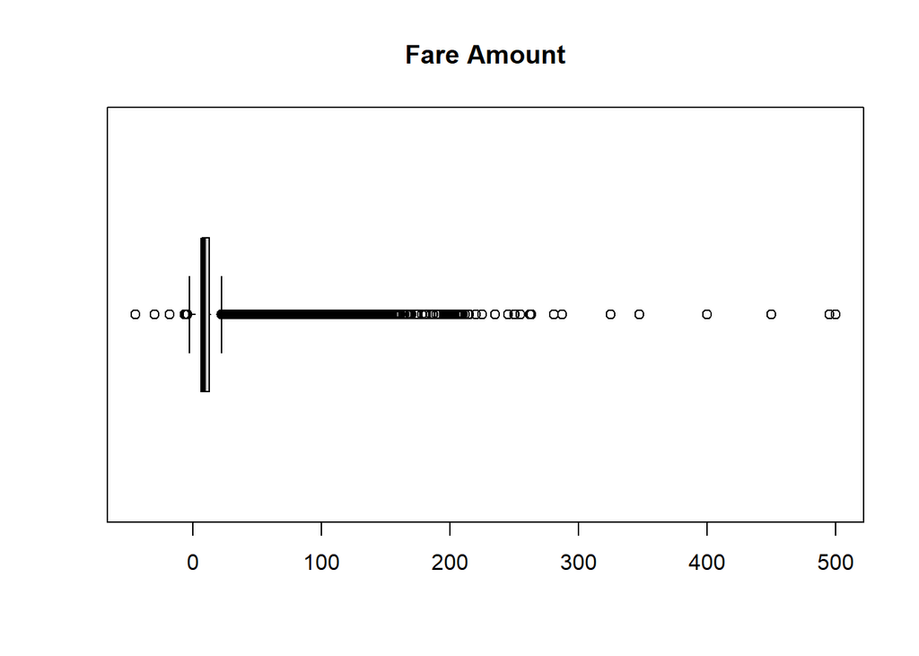

```r
boxplot(df$fare_amount,horizontal = T,main='Fare Amount')
```

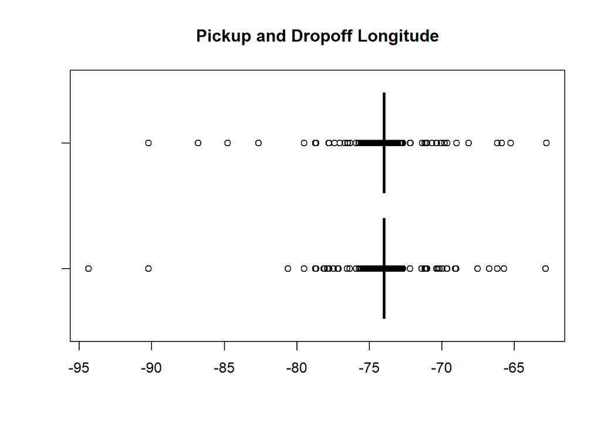

```r
boxplot(df$pickup_longitude,df$dropoff_longitude,horizontal = T,main='Pickup and Dropoff Longitude')
```

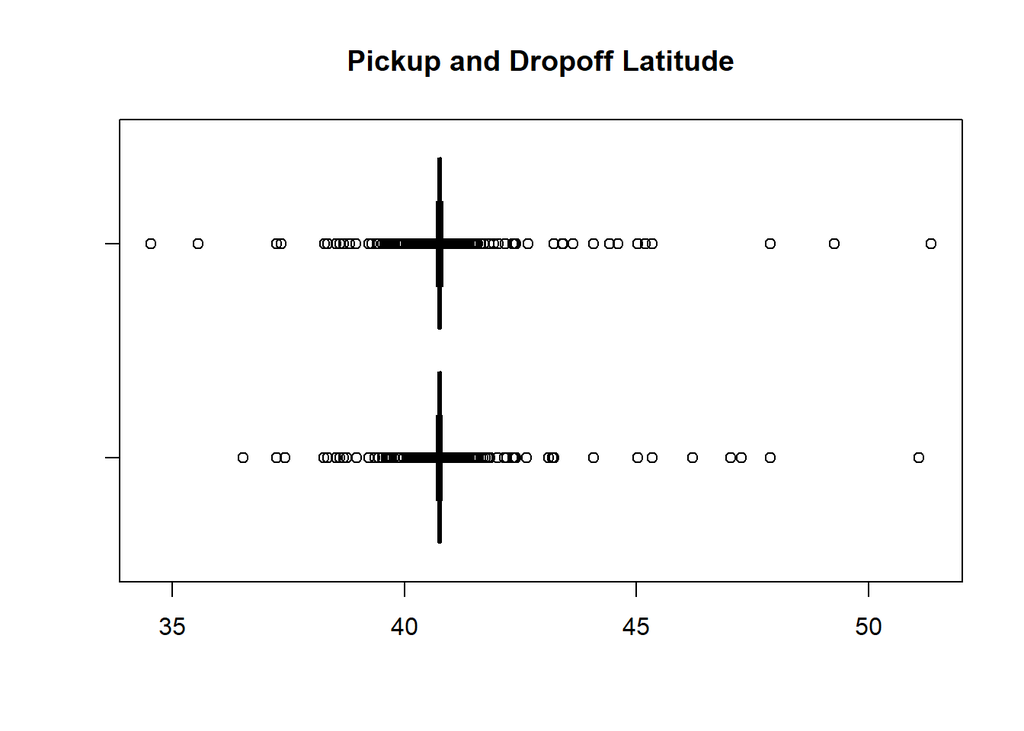

```r
boxplot(df$pickup_latitude,df$dropoff_latitude,horizontal = T,main='Pickup and Dropoff Latitude')
```

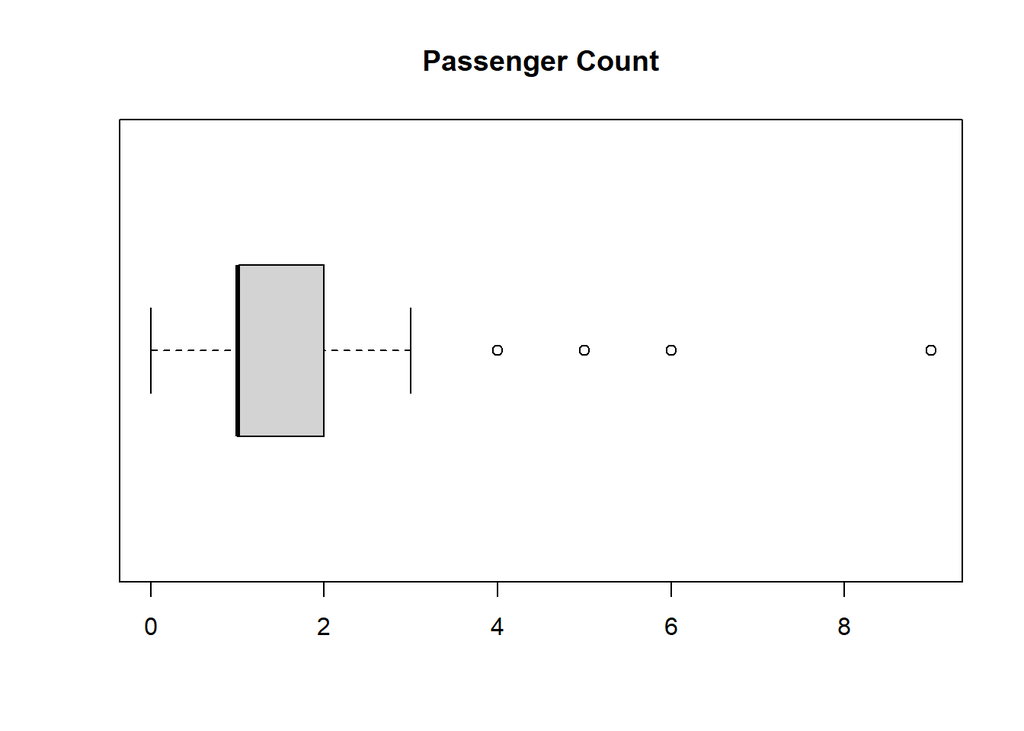

```r
boxplot(df$passenger_count,horizontal = T,main='Passenger Count')
```

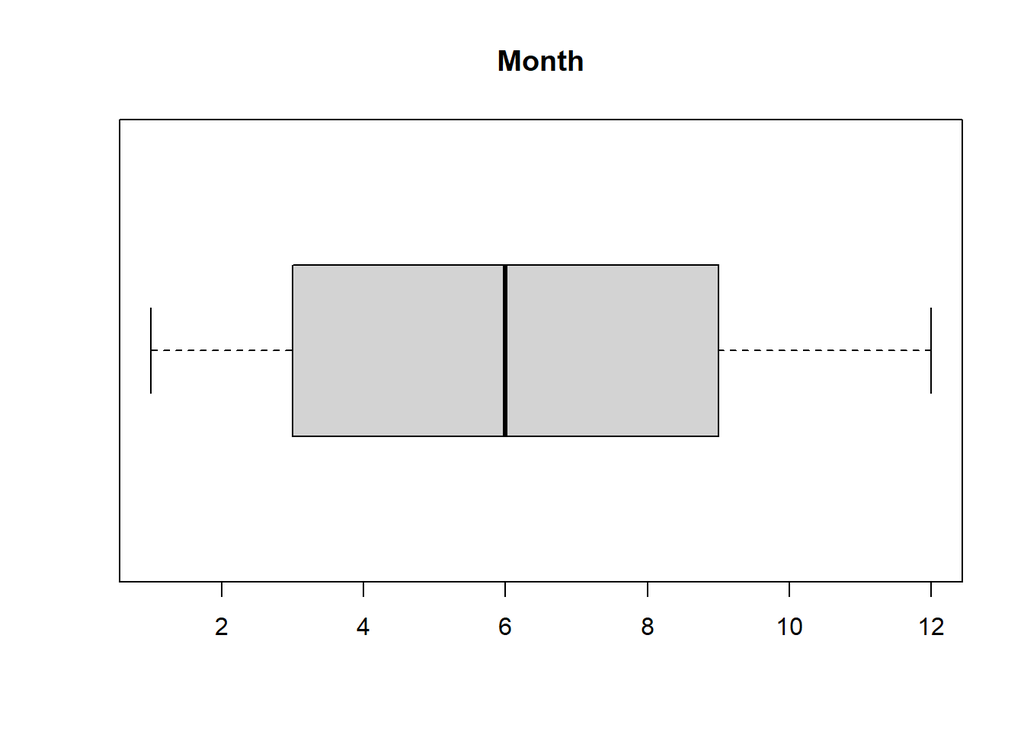

```r
boxplot(month(df$date),horizontal = T,main='Month')
```

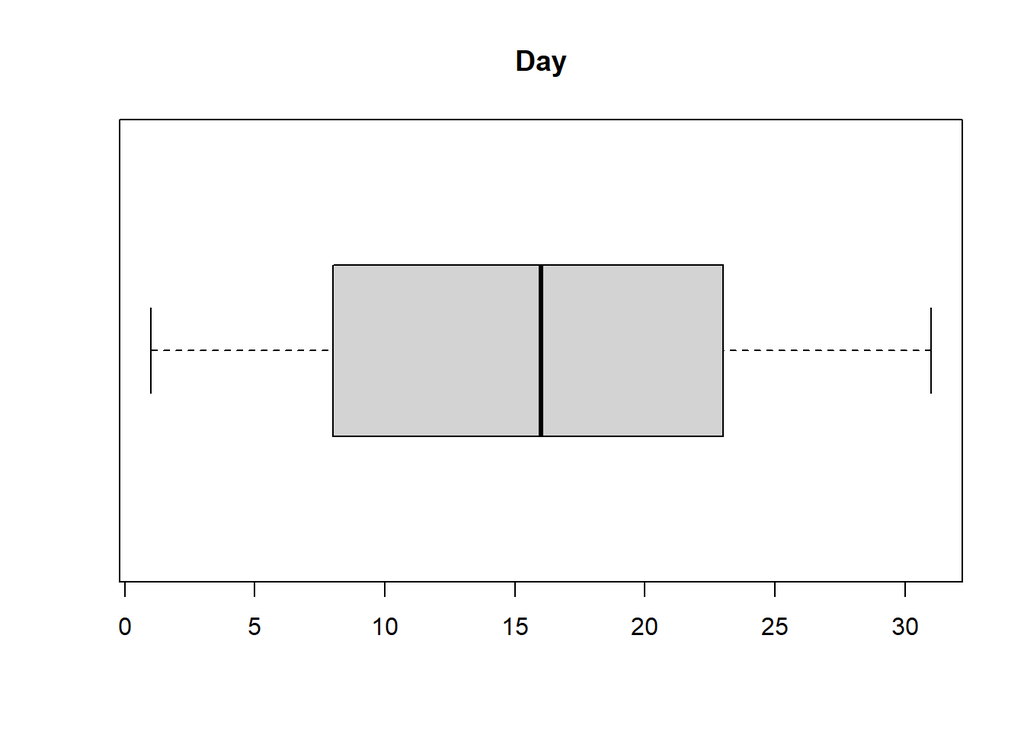

```r
boxplot(day(df$date),horizontal = T,main='Day')
```

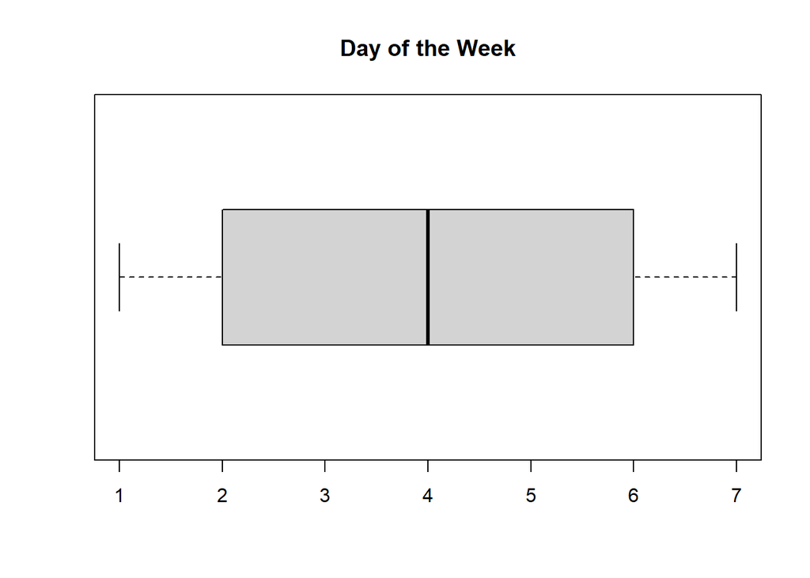

```r
boxplot(wday(df$date),horizontal = T,main='Day of the Week')
```

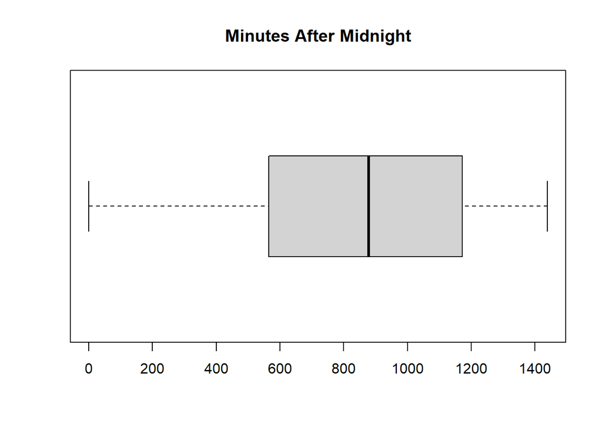

```r
boxplot(df$min_after_midnight,horizontal = T,main='Minutes After Midnight')
```

To finish, the date and time columns were removed to save space and the data was split into a test and training set.

```r
#remake final df
df<-subset(df,select = c(-date,-time))

#split test and train data
train.rows <- sample(nrow(df), nrow(df) * .8)
df_train <- df[train.rows, ]
df_test <- df[-train.rows, ]
```

## Model Creation

To make our predictions, we decided to use eXtreme Gradient Boosting. We decided to use this type of model given that it is currently the industry standard and works well regardless of the amount of features. To find the best parameters, a grid search was created. There are definitely many more parameters that could have been used in the search, but unfortunately, time was a factor. This model took approximately six hours to run, and that was with 1.5% of the original dataset. Had there been more time and computing power, many more values could have been tested and the final output would likely have been better.

First, the tuning grid was created. The boosting iterations were tested for a range of 100 to 1000. Shrinkage was tested from 0.025 to 0.3 and the max tree depth ranged from 2 to 6. All other parameters were given default values.

```r
#create tuning grid
tune_grid <- expand.grid(
  nrounds = seq(from = 100, to = 1000, by = 50),
  eta = c(0.025, 0.05, 0.1, 0.3),
  max_depth = c(2, 3, 4, 5, 6),
  gamma = 0,
  colsample_bytree = 1,
  min_child_weight = 1,
  subsample = 1
)
```

Next the tuning controller was created. This used four fold cross validation.

```r
#create tuning controller
tune_control <- trainControl(
  method = "cv",
  number = 4,
  verboseIter = FALSE, # no training log
  allowParallel = TRUE # FALSE for reproducible results
)
```

## Final Results

```r
#calculate the RMSE
model_rmse <- rmse(df_test[,1], predict(xgb_tune$finalModel, newdata = model.matrix(~.-fare_amount, data=df_test)))
#print rmse
cat('RMSE:',as.character(model_rmse))
```

```
## RMSE: 4.18494250973368
```

```r
#print model characteristics
print(xgb_tune$bestTune)
```

```
##     nrounds max_depth eta gamma colsample_bytree min_child_weight subsample
## 285    1000         6 0.1     0                1                1         1
```

```r
print(xgb_tune$finalModel)
```

```
## ##### xgb.Booster
## raw: 6.1 Mb
## call:
##   xgboost::xgb.train(params = list(eta = param$eta, max_depth = param$max_depth,
##     gamma = param$gamma, colsample_bytree = param$colsample_bytree,
##     min_child_weight = param$min_child_weight, subsample = param$subsample),
##     data = x, nrounds = param$nrounds, verbose = TRUE, objective = "reg:linear")
## params (as set within xgb.train):
##   eta = "0.1", max_depth = "6", gamma = "0", colsample_bytree = "1", min_child_weight = "1", subsample = "1", objective = "reg:linear", validate_parameters = "TRUE"
## xgb.attributes:
##   niter
## callbacks:
##   cb.print.evaluation(period = print_every_n)
## # of features: 54
## niter: 1000
## nfeatures : 54
## xNames : (Intercept) pickup_longitude pickup_latitude dropoff_longitude dropoff_latitude passenger_count month2 month3 month4 month5 month6 month7 month8 month9 month10 month11 month12 day2 day3 day4 day5 day6 day7 day8 day9 day10 day11 day12 day13 day14 day15 day16 day17 day18 day19 day20 day21 …
## problemType : Regression
## tuneValue :
##      nrounds max_depth eta gamma colsample_bytree min_child_weight subsample
## 285    1000         6 0.1     0                1                1         1
## obsLevels : NA
## param :
##  $verbose
## [1] TRUE
```